# 统计检验力（功效）分析共同笔记

### 2.3.7 例子1

```r
design_result <- ANOVA_design(design = "2b*2w",
                   n = 40,
                   mu = c(1.03, 1.41, 0.98, 1.01),
                   sd = 1.03,
                   r=0.8,
                   labelnames = c("voice", "human", "robot", "emotion", "cheerful", "sad"))
```

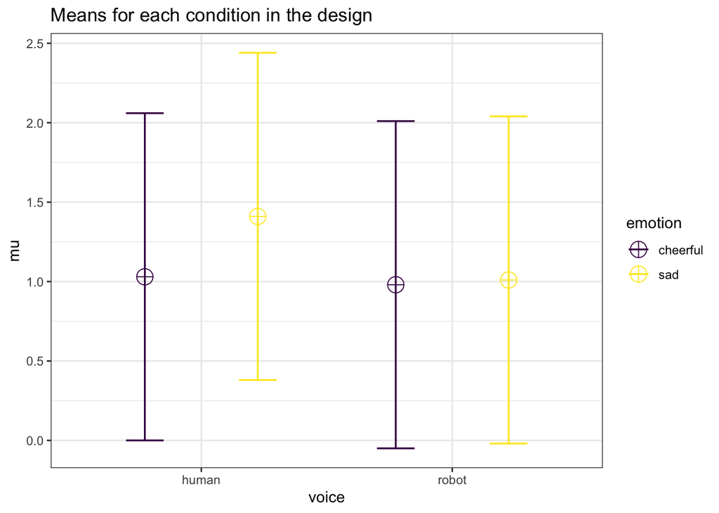

```r
nsims <- 1000 # 注：此处根据实际需要修改，例如上文提到的先设定成100，如果正确的话再修改为1000，根据需要可进一步增加，例如增加至100000
power_result_vig_1 <- ANOVA_power(design_result,
                                   alpha = 0.05,
                                   nsims = nsims,
                                   seed = 1234)
```

```
## Power and Effect sizes for ANOVA tests
##                     power effect_size
## anova_voice          18.2     0.02612
## anova_emotion        80.4     0.10113
## anova_voice:emotion  68.1     0.08262
##
## Power and Effect sizes for pairwise comparisons (t-tests)
##                                                             power effect_size
## p_voice_human_emotion_cheerful_voice_human_emotion_sad       95.5     0.60464
## p_voice_human_emotion_cheerful_voice_robot_emotion_cheerful   5.1    -0.04635
## p_voice_human_emotion_cheerful_voice_robot_emotion_sad        5.3    -0.02273
## p_voice_human_emotion_sad_voice_robot_emotion_cheerful       47.1    -0.42257
## p_voice_human_emotion_sad_voice_robot_emotion_sad            41.9    -0.39998
## p_voice_robot_emotion_cheerful_voice_robot_emotion_sad        4.9     0.03820
##
##
## Within-Subject Factors Included: Check MANOVA Results
```

```r
# reduce file size for github - only save what is needed
power_result_vig_1$sim_data <- NULL
#power_result_vig_1$plot1 <- NULL
power_result_vig_1$plot2 <- NULL
# 可根据实际需要进行修改
```

```r
saveRDS(power_result_vig_1, file = "power_result_vig_1.rds")
power_result_vig_1 <- readRDS(file = "power_result_vig_1.rds")
#可根据实际需要修改路径
```

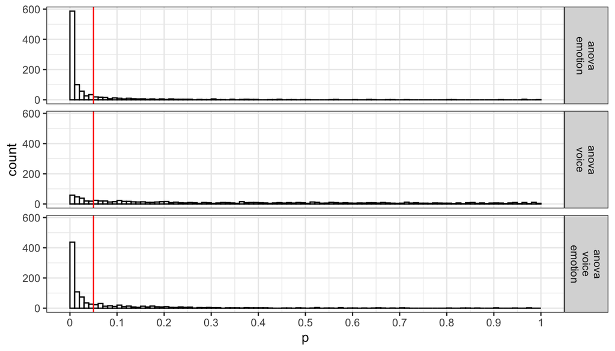

```r
power_result_vig_1$plot1
```

```r
power_result_vig_1$main_results
```

```
##                     power effect_size
## anova_voice          18.2  0.02611979
## anova_emotion        80.4  0.10113363
## anova_voice:emotion  68.1  0.08261606
```

统计检验力模拟的结果输出如上。结果主要分为2个部分（可以通过将`verbose`设定为`FALSE`将结果压缩显示）。第一个表格提供了ANOVA的统计检验力（从0到100%）和效应量（partial eta-squared）。我们可以看到针对声音、情绪和声音*情绪的主效应的结果。

统计检验力模拟的结果显示情绪的主效应的统计检验力最高。因为情绪是被试内因素,并且平均数高度相关（0.8），所以针对被试内的对比，我们拥有较高的统计检验力。针对交互作用，统计检验力较低，并且声音的主效应非常低。

ANOVA分析的后续一般为事后比较。统计假设通常不只预测交互作用存在，还预测交互作用的方向。如上图所示，我们可能只对高兴和悲伤的类人声声音助理的独立效应和悲伤的类机器人和类人的声音的差异感兴趣。第二个表格显示了针对所有事后比较的*t*检验的统计检验力和效应量（针对被试间对比为Cohen’s d，针对被试内对比为Cohen’s $d_z$，针对被试内对比，见Lakens, 2013）。

通常针对被试内因素，不同实验条件下的差异的统计检验力比较高， 而对于相似的平均数（例如，1.03，0.98和1.01）之间的微小差异的统计检验力非常低。除以上两个表格之外，`ANOVA_power` 函数可以返回初始的模拟数据（针对每一个模拟的 *p* 值和效应量，见`simulation_result$sim_data`）和包含所有ANOVA检验中的 *p* 值分布的图表。

### 2.3.8 例子2

假设我们计划设计一个研究来检验如下假设：照顾宠物可以提升人们的生活满意度。我们有一个控制组和一个实验组（被试有一个需要照顾的宠物），将被试随机分配到这两种组别中。我们可以模拟一个设定了alpha，样本量和效应量的One-Way ANOVA，来计算相应的统计检验力。我们预期相比于控制组，实验组中的宠物可以提升被试的生活满意度。基于Pavot和Diener（1993）的工作成果，我们相信在总体中针对生活满意度的测量均值约为24，标准差约为6.4。我们期望针对拥有宠物的被试，宠物约可以提升2.2的生活满意度分数。我们计划一共收集200个被试的数据，每一个实验条件下随机分配100名被试。我们通过如下步骤来检验这个实验设计的统计检验力：

```r
design <- "2b"
n <- 100
mu <- c(24, 26.2)
sd <- 6.4
labelnames <- c("condition", "control", "pet") #

design_result <- ANOVA_design(design = design,
                              n = n,
                              mu = mu,
                              sd = sd,
                              labelnames = labelnames)
```

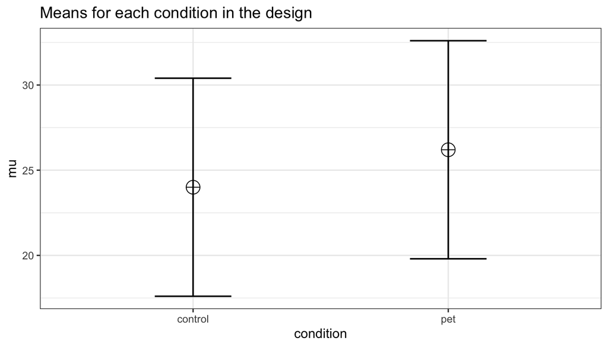

```r
nsims <- 1000 # 注：此处根据实际需要修改，例如上文提到的先设定成100，如果正确的话再修改为1000

power_result_vig_2 <- ANOVA_power(design_result, nsims = nsims, seed = 1234)
```

```
## Power and Effect sizes for ANOVA tests
##                 power effect_size
## anova_condition  68.1     0.03432
##
## Power and Effect sizes for pairwise comparisons (t-tests)
##                                   power effect_size
## p_condition_control_condition_pet  68.1       0.352
```

```r
#
# reduce file size for github - only save what is needed
power_result_vig_2$sim_data <- NULL
# power_result_vig_2$plot1 <- NULL
power_result_vig_2$plot2 <- NULL
saveRDS(power_result_vig_2, file = "power_result_vig_2.rds")
power_result_vig_2 <- readRDS(file = "power_result_vig_2.rds")

# 注：在ANOVA_design函数中，默认值为r = 0，在ANOVA_power函数中，alpha的默认值为0.05。
```

结果显示针对ANOVA，我们有和*t*检验一样的统计检验力结果，原因是在这个例子中只有2组被试。在这个研究中，每一组有100名被试，相应的统计检验力相对来说很低（在67.7%左右）。

只有两组被试的ANOVA和*t*检验是一样的，在上述例子中，针对控制组和实验组差异的Cohen’s d（标准均差）是d = 2.2/6.4 = 0.34375，可以很容易地通过`pwr`包来计算简单比较的预期的统计检验力。

```r
library(pwr)
pwr.t.test(d = 2.2/6.4,
           n = 100,
           sig.level = 0.05,
           type="two.sample",
           alternative="two.sided")$power
```

```
## [1] 0.6768572
```

我们也可以通过两个组别的Cohen’s d来直接计算Cohen’s f，正如Cohen（1988）提出的，$f = \frac{1}{2}d$。所以$f = 0.5*0.34375 = 0.171875$。事实上，使用`pwr`包中`pwr.anova.test`所计算的统计检验力与`power.t.test`结果一致。

```r
pwr.anova.test(n = 100,
               k = 2,
               f = 0.171875,
               sig.level = 0.05)$power
```

```
## [1] 0.6768572
```

以上分析表明使用每组包含100名被试的实验设定不太会导致显著的统计结果，即使我们所期望的差异是真实存在的。这显然不是最优的结果。如果我们进行一项研究，我们希望可以得到信息丰富的结果，也就是说如果效应存在，我们就应该可以探测到所期望的或者所关心的这个效应；如果效应不存在，我们就应该探测不到这个效应。

如果想达到足够的统计检验力，我们究竟需要多少被试呢？考虑到预期的差异和标准差，d = 0.34375，f = 0.171875。我们可以增大样本量进而进行模拟，直到满意为止。统计检验力与二型错误的概率密切相关。Cohen建议将所寻求的统计检验力的标准设为80%，即二型错误的概率为20%。我个人认为20%的二型错误概率太高，并且与设定地更加严格地一型错误概率（尽管你可以通过调整样本量和平衡错误率来降低它，从而证明alpha的值是正确的，但通常设定为5%）相比并不相称。假设我们在这里想达到90%的统计检验力。

当你在增加样本量来找出究竟实验设计中需要多少被试的时候，使用`ANOVA_exact`函数更为有效率。你可以看到在如下代码中我们慢慢地增加样本量，发现180个被试时可达到略高于90%的统计检验力。

```r
design_result <- ANOVA_design(design = "2b",
                   n = 100,
                   mu = c(24, 26.2),
                   sd = 6.4,
                   labelnames = c("condition", "control", "pet"))
```

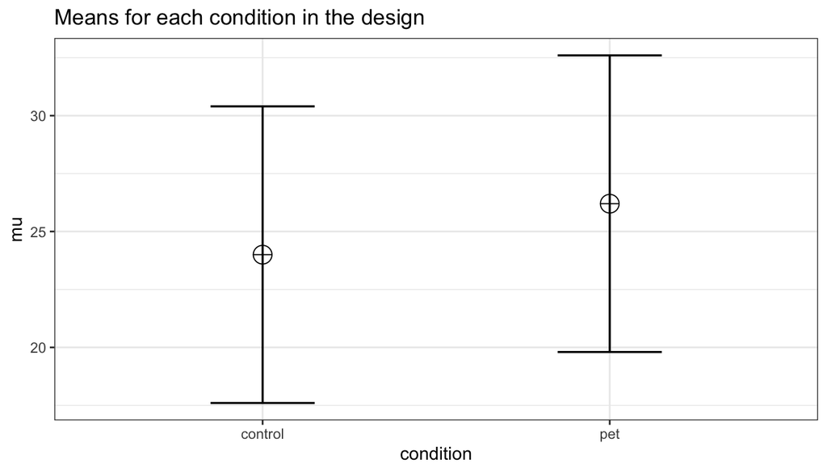

```r
ANOVA_exact(design_result)$main_results$power
```

```
## Power and Effect sizes for ANOVA tests
##             power partial_eta_squared cohen_f non_centrality
## condition 67.6857               0.029  0.1727         5.9082
##
## Power and Effect sizes for pairwise comparisons (t-tests)
##                                   power effect_size
## p_condition_control_condition_pet 67.69        0.34
```

```
## [1] 67.68572
```

统计检验力为67.7%，此结果较低，因此我们将样本量从每组100人升至150人来看结果是否更接近我们的目标 - 统计检验力达到90%。

```r
design_result <- ANOVA_design(design = "2b",
                   n = 150,
                   mu = c(24, 26.2),
                   sd = 6.4,
                   labelnames = c("condition", "control", "pet"),
                   plot = FALSE)

ANOVA_exact(design_result)$main_results$power
```

```
## Power and Effect sizes for ANOVA tests
##             power partial_eta_squared cohen_f non_centrality
## condition 84.3127              0.0289  0.1725         8.8623
##
## Power and Effect sizes for pairwise comparisons (t-tests)
##                                   power effect_size
## p_condition_control_condition_pet 84.31        0.34
```

```
## [1] 84.3127
```

此次统计检验力达到84.31%，但仍然不够，我们试一下每组175人。

```r
design_result <- ANOVA_design(design = "2b",
                   n = 175,
                   mu = c(24, 26.2),
                   sd = 6.4,
                   labelnames = c("condition", "control", "pet"),
                   plot = FALSE)

ANOVA_exact(design_result)$main_results$power
```

```
## Power and Effect sizes for ANOVA tests
##             power partial_eta_squared cohen_f non_centrality
## condition 89.3735              0.0289  0.1724        10.3394
##
## Power and Effect sizes for pairwise comparisons (t-tests)
##                                   power effect_size
## p_condition_control_condition_pet 89.37        0.34
```

```
## [1] 89.37347
```

结果为89.37%，非常接近我们的目标，因此再稍添一些被试，我们来试一下每组180人的情况。

```r
design_result <- ANOVA_design(design = "2b",
                   n = 180,
                   mu = c(24, 26.2),
                   sd = 6.4,
                   labelnames = c("condition", "control", "pet"),
                   plot = FALSE)

ANOVA_exact(design_result)$main_results$power
```

```
## Power and Effect sizes for ANOVA tests
##             power partial_eta_squared cohen_f non_centrality
## condition 90.1886              0.0288  0.1724        10.6348
##
## Power and Effect sizes for pairwise comparisons (t-tests)
##                                   power effect_size
## p_condition_control_condition_pet 90.19        0.34
```

```
## [1] 90.18863
```

此次的结果为90.19%。

### 2.3.9 Plot_power函数

基于模拟的统计检验力分析需要你来增加样本量，直到统计检验力足够高来达到理想的二型错误率。为加速这个过程，我们可以使用`plot_power`函数来画出随着样本量的变化，统计检验力随之变化的曲线。

`plot_power`这个函数需要如下输入：`ANOVA_design`, `max_n`和`plot`。

1. `design_result`：由`ANOVA_design`函数得到的输出（保存为一个对象）
2. `min_n`：统计检验力曲线中的最小样本量
3. `max_n`：统计检验力曲线中的最大样本量
4. `plot`: 如果不输出图像，则设定为`FALSE`（Github教程提到，默认值为`FALSE`，但是运行code时发现，默认值应该是`TRUE`，为保证未来code的一致性，建议将`plot = TRUE`写出）

`plot_power`函数可以使用`ANOVA_exact`函数来模拟直至`max_n`样本量的统计检验力。即使这种方法速度稍快，当样本量较大时还是需要不少时间来得出结果。如下图所示，我们可以看出，假设平均数和标准差真正的模式可代表我们所期望的平均数和标准差的模式，在每组有135名被试的情况下，我们可以得到约80%的统计检验力;在每组有180名被试的情况下，我们可以得到约90%的统计检验力；在每组有225名被试的情况下，我们可以得到约95%的统计检验力。

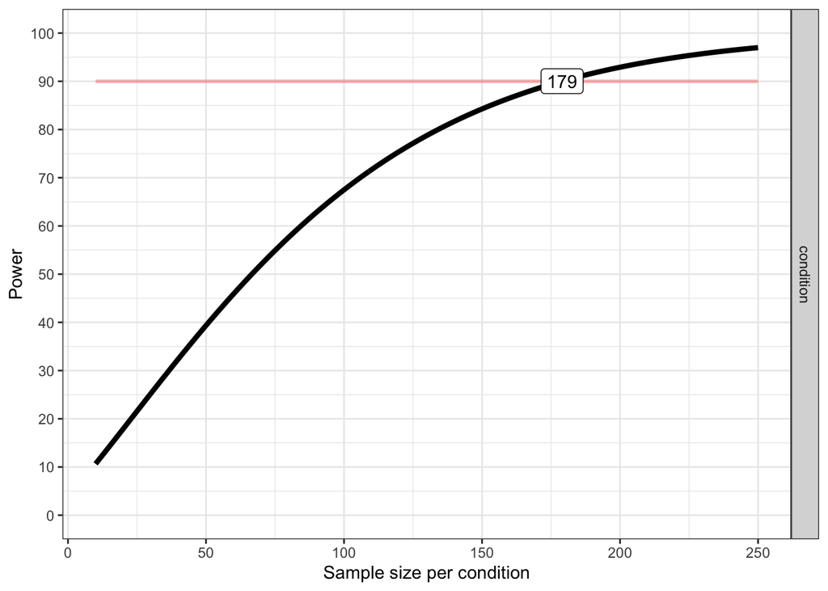

```
## Achieved Power and Sample Size for ANOVA-level effects
##    variable                  label   n achieved_power desired_power
## 1 condition Desired Power Achieved 179          90.03            90
```

```r
plot_power(design_result, min_n = 10, max_n = 250, plot = TRUE)
```

由于平均数的真正的模式是不知道的，检验一定范围内的统计检验力是非常明智的。举例来说，假如平均数之间的差别非常小（假如平均数分别为24和26，而不是24和26.2），我们可以将上图中的统计检验力曲线和此略不乐观情况下（真正的效应量稍小）的统计检验力曲线进行对比。

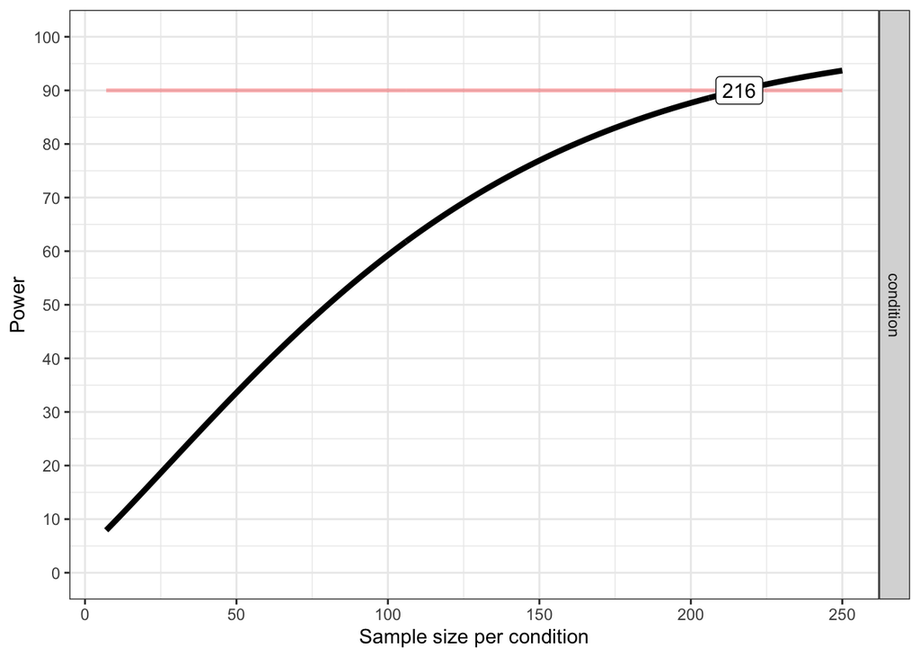

```
## Achieved Power and Sample Size for ANOVA-level effects
##    variable                  label   n achieved_power desired_power
## 1 condition Desired Power Achieved 216          90.01            90
```

```r
design_result <- ANOVA_design(design = "2b",
                   n = 180,
                   mu = c(24, 26),
                   sd = 6.4,
                   labelnames = c("condition", "control", "pet"),
                   plot = FALSE)

plot_power(design_result, max_n = 250, plot = TRUE)
```

除效应量可能较小之外，标准差也可能比我们所期望的稍大。这也会进一步降低统计检验力，并且这比上面提到的情况更为不理想。我们假设真正的标准差为6.8而不是6.4。

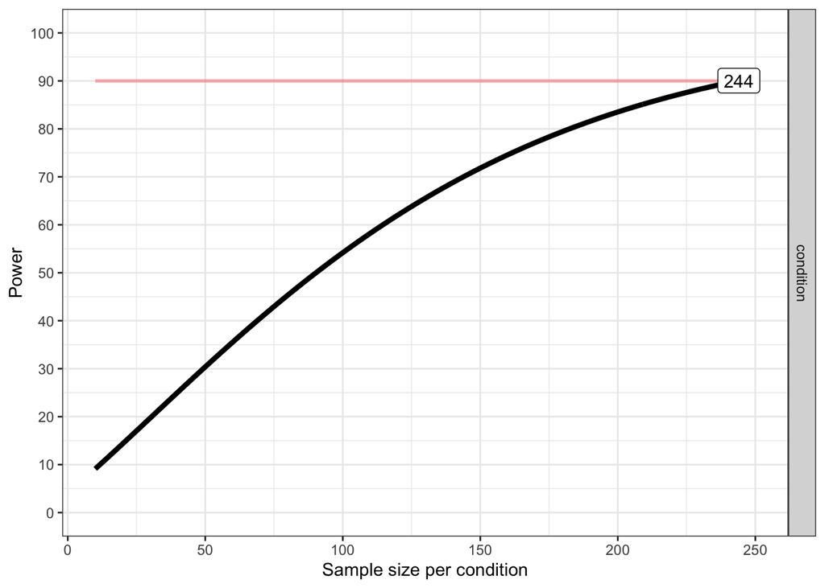

```
## Achieved Power and Sample Size for ANOVA-level effects
##    variable                  label   n achieved_power desired_power
## 1 condition Desired Power Achieved 244          90.05            90
```

```r
design_result <- ANOVA_design(design = "2b",
                   n = 180,
                   mu = c(24, 26),
                   sd = 6.8,
                   labelnames = c("condition", "control", "pet"),
                   plot = FALSE)

plot_power(design_result, min_n = 10, max_n = 250, plot = TRUE)
```

就像这些不同的图像所示，你的研究永远不可能真正地知道统计检验力。因为真正的效应量（例如，平均数和标准差的模式）未知，那么真正的统计检验力也是未知的。假设在一个特定的效应量的值下，一个研究可达到90%的统计检验力，但是如果真正的效应量与你所期望的数值不同，那么真正的统计检验力就会较高或较低。因此，当执行先验统计检验力分析时，我们应该讨论的是“期望的”统计检验力，并且应该为我们的期望提供证据（例如，被试内设计的平均数、标准差和相关的模式）。

### 2.3.10 其他例子

#### 2.3.10.1 例子3:三组被试间设计的统计检验力

假如我们计划设计一项研究来检验如下假设：照顾宠物可以提升人们的生活满意度。我们有一个控制组、一个宠物为猫的实验组和一个宠物为狗的实验组。我们可以模拟一个拥有设定的alpha、样本量和效应量的One-Way ANOVA来计算ANOVA和相应的事后比较的统计检验力。我们假设和控制组相比，所有的拥有宠物组都可以提升生活满意度。并且，我们假设养狗的被试比养猫的被试的生活满意度要高。基于Pavot和Diener（1993）的研究成果，我们再一次假设在总体中针对生活满意度的测量均值约为24，标准差约为6.4。我们期望猫作为宠物可提升生活满意度约2.2个点，狗作为宠物可提升生活满意度约2.6个点。作为开始，我们收集150名被试的数据，每组50人。但是在收集数据之前，我们先计算统计检验力来看是否可以检验到我们所期望的差异。

```r
design <- "3b"
n <- 50
mu <- c(24, 26.2, 26.6)
sd <- 6.4
labelnames <- c("condition", "control", "cat", "dog") #

design_result <- ANOVA_design(design = design,
                   n = n,
                   mu = mu,
                   sd = sd,
                   labelnames = labelnames)
```

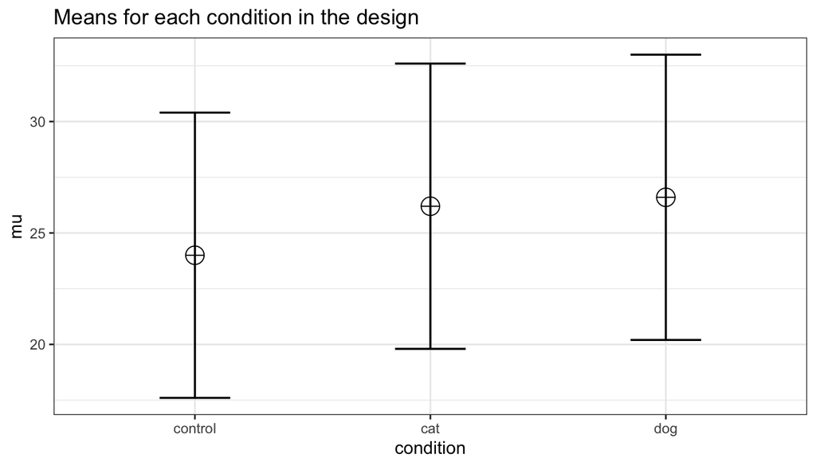

```r
ANOVA_exact(design_result)
```

```
## Power and Effect sizes for ANOVA tests
##             power partial_eta_squared cohen_f non_centrality
## condition 47.6947              0.0315  0.1804         4.7852
##
## Power and Effect sizes for pairwise comparisons (t-tests)
##                                   power effect_size
## p_condition_control_condition_cat 39.83        0.34
## p_condition_control_condition_dog 52.05        0.41
## p_condition_cat_condition_dog      6.10        0.06
```

结果显示，当每组有50个被试时，不论是总体的ANOVA（略低于50%）还是事后比较（控制组对比养猫组约为40%，控制组对比养狗组约为50%，养猫组和养狗组之间的差异的统计检验力极低，约为6%，只比一型错误率5%高一点点）统计检验力很低。我们可以很容易地使用`pwr`包来确认针对这些简单比较所期望的统计检验力。在我们的例子中，控制组和养猫组之间的差异的Cohen’s d（标准均差）是$2.2/6.4 = 0.34375$，控制组和养狗组之间的差异的Cohen’s d是$2.6/6.4 = 0.40625$，养猫组和养狗组之间的差异的Cohen’s d是$0.4/6.4 = 0.0625$

```r
pwr.t.test(d = 2.2/6.4,
           n = 50,
           sig.level = 0.05,
           type="two.sample",
           alternative="two.sided")$power
```

```
## [1] 0.3983064
```

```r
pwr.t.test(d = 2.6/6.4,
           n = 50,
           sig.level = 0.05,
           type="two.sample",
           alternative="two.sided")$power
```

```
## [1] 0.5205162
```

```r
pwr.t.test(d = 0.4/6.4,
           n = 50,
           sig.level = 0.05,
           type="two.sample",
           alternative="two.sided")$power
```

```
## [1] 0.06104044
```

很显然，我们需要更多的被试来提高统计检验力。让我们来画一个统计检验力随着样本量变化的曲线来看我们要增加多少样本。

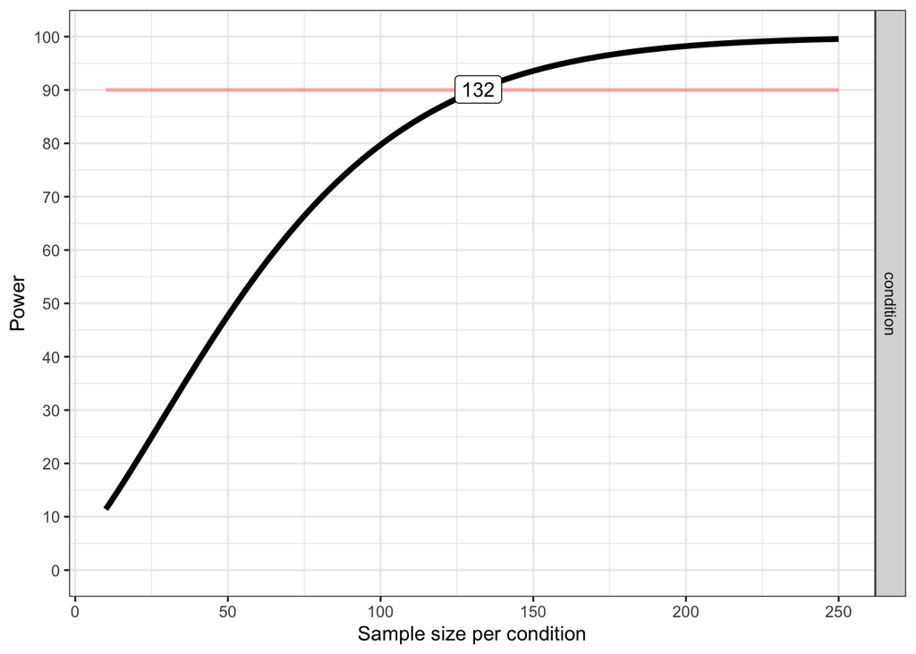

```
## Achieved Power and Sample Size for ANOVA-level effects
##    variable                  label   n achieved_power desired_power
## 1 condition Desired Power Achieved 132           90.1            90
```

```r
plot_power(design_result, min_n = 10, max_n = 250, plot = TRUE)
```

我们可以看出在拥有132名被试时，针对ANOVA我们可以得到约90%的统计检验力。但是我们也需要检查针对控制组和养猫组的比较的统计检验力。

```r
design <- "3b"
n <- 132
mu <- c(24, 26.2, 26.6)
sd <- 6.4
labelnames <- c("condition", "control", "cat", "dog") #

design_result <- ANOVA_design(design = design,
                   n = n,
                   mu = mu,
                   sd = sd,
                   labelnames = labelnames,
                   plot = FALSE) #do not print the plot (same as above)

ANOVA_exact(design_result)
```

```
## Power and Effect sizes for ANOVA tests
##            power partial_eta_squared cohen_f non_centrality
## condition 89.715              0.0311  0.1793        12.6328
##
## Power and Effect sizes for pairwise comparisons (t-tests)
##                                   power effect_size
## p_condition_control_condition_cat 79.46        0.34
## p_condition_control_condition_dog 90.80        0.41
## p_condition_cat_condition_dog      7.98        0.06
```

```r
n <- 180
design_result <- ANOVA_design(design = design,
                   n = n,
                   mu = mu,
                   sd = sd,
                   labelnames = labelnames,
                   plot = FALSE) #do not print the plot (same as above)

ANOVA_exact(design_result)
```

```
## Power and Effect sizes for ANOVA tests
##             power partial_eta_squared cohen_f non_centrality
## condition 96.7794              0.0311  0.1791        17.2266
##
## Power and Effect sizes for pairwise comparisons (t-tests)
##                                   power effect_size
## p_condition_control_condition_cat 90.19        0.34
## p_condition_control_condition_dog 97.02        0.41
## p_condition_cat_condition_dog      9.09        0.06
```

```r
n <- 5380
design_result <- ANOVA_design(design = design,
                   n = n,
                   mu = mu,
                   sd = sd,
                   labelnames = labelnames,
                   plot = FALSE) #do not print the plot (same as above)

ANOVA_exact(design_result)
```

```
## Power and Effect sizes for ANOVA tests
##           power partial_eta_squared cohen_f non_centrality
## condition   100              0.0309  0.1786       514.8828
##
## Power and Effect sizes for pairwise comparisons (t-tests)
##                                   power effect_size
## p_condition_control_condition_cat   100        0.34
## p_condition_control_condition_dog   100        0.41
## p_condition_cat_condition_dog        90        0.06
```

当每组有132名被试时，控制组和养猫组的简单比较的统计检验力只有80%。如果我们针对事后比较都想达到90%的统计检验力，我们需要更多的被试。180名被试可以为控制组和养猫组的事后比较提供较好的统计检验力。但是养猫组和养狗组之间差异的统计检验力极低。我们需要5380名被试来使得此事后比较组达到90%的统计检验力。如果收集数据很容易，那么达到5380名被试是可能的。但是如果数据收集的代价非常高，就使得我们不可能真正得到这个问题的可靠答案。明白不可能可靠地研究一个问题是分析先验统计检验力非常重要的一个方面。

#### 2.3.10.2 例子4:重复测量ANOVA的统计检验力

在重复测量设计中，多次的测量数据是从相同的被试来收集的。最简单的情境为有两个重复测量的数据，那么重复测量ANOVA等同于非独立样本或配对样本*t*检验。让我们来看一下此中相关对于重复测量ANOVA的统计检验力的影响。

##### 2.3.10.2.1 样本内的两次测量的情况

为解释相关观测的影响，我们由非独立（或配对、被试内）*t*检验的中等效应量开始来模拟数据。我们首先来看G*Power。假如我们想执行一个先验统计检验力分析，我们需要先提供效应量$d_Z$。正如Cohen（1988）所提出的，其中下角标Z是用来强调的初始数据的单位不再是X或者Y，而是Z这一事实，Z是X-Y的差异数。

因为数据之间是相关的，被试内设计比被试间设计在探测差异时拥有更高的统计检验力，并且因为每一个被试可提供多次观测数据，被试内设计需要更少的被试。独立样本*t*检验和非独立样本*t*检验的一个区别就是独立样本*t*检验的自由度为$2(n-1)$，而非独立样本*t*检验的自由度为$(n-1)$。假设正态分布且忽视两种检验类型在自由度上的不同，两组被试内设计（NW）的样本量相对于两组被试间设计（NB）的样本量为（Maxwell & Delaney, 2004, p. 561, eq. 45）：

$$N_W = \frac{N_B(1-\rho)}{2}$$

在公式中，除以2是因为在被试内两实验条件的设计中，每一个被试都可提供2个数据。与被试间设计相比，被试内实验设计可减少样本量的程度基于两变量的相关程度（*r*），如公式中$1-r$的部分所示。如果相关为0，那么正因为每一个被试能提供两个数据点，被试内实验设计需要被试间实验设计的一半被试量（例如，需要64个而不是128个）。相关越高，被试内实验设计相对的好处越大，但是当相关为负的时候（最多至-1），这种好处就消失了。

在独立样本*t*检验中，两次观测是不相关的，而在被试内设计中，观测是相关的。这就对数据间差异的标准差产生影响。反过来，因为标准效应量是均差除以数据间差异的标准差，那么相关就会对被试内设计的标准化的均差产生影响，Cohen’s $d_Z$。正如Cohen（1988, eq. 2.3.7）所解释的，它们之间的关系为：

$$\sigma_Z=\sigma\sqrt{2(1-\rho)}$$

因此，$d_Z$和d之间的关系为$\sqrt{2(1-\rho)}$。正如Cohen（1988）所写：“用另一种说法来说，一个针对配对（非独立）样本的总体平均数之间的给定差异是由与其样本独立时的一样大的$\sqrt{2(1-\rho)}$这个值标准化的。”

如果我们将相关设定为0.5，则$\sqrt{2(0.5)}=1$。当相关为0.5时，$d=d_Z$。当变量间相关变强时，例如$r=0.9$，我们可以得到$d=d_Z\sqrt{2(1-0.9)}$，当$d_Z$为1时，$d=0.45$。反过来，$d_Z=\frac{d}{\sqrt{2(1-r)}}$，所以当$r=0.9，d=1$时，我们可以得到$d_Z=2.24$。一些观点认为，当观测值都与估计效应量的“膨胀”强相关时，此相关可导致更容易地从“噪声”中区分出假设检验中的“信号”，由此又可导致数据间差异的标准差的降低，因此与d相比，$d_Z$的增长会导致非常明确的统计检验力上的优势。

在被试内ANOVA中，没有与Cohen’s f相对应的$f_Z$。针对包含两个组别的实验设计，正如Cohen（1988）所提到的，我们可以使用$f=\frac{1}{2}d$直接从Cohen’s d计算Cohen’s f。若$d=0.5$，则$f=0.25$。在G*Power中，我们可以执行一个被试内2组实验设计ANOVA的统计检验力分析。我们将预期达到的统计检验力设为80%，通过非独立样本*t*检验来执行这个分析。之所以可行是因为当$d=d_Z$时，相关被设定为0.5，所以$f=\frac{1}{2}d$的转换有效。

如果我们将相关改为0.7，并且保持其他设定不变，那么重复测量的先验统计检验力可得出样本量为21。那么相关的增加导致了统计检验力的增加。

为了在G*Power中使用非独立样本*t*检验来复现这个分析，我们需要根据$d_Z=\frac{0.5}{\sqrt{2(1-0.7)}}$来调整$d_Z$，得到$d_Z=0.6454972$。如果在G*Power中的先验概率分析中输入这个值，可得到一致的结果（因为拥有两组或两次测量的重复测量ANOVA与非独立样本*t*检验一致）。这个例子说明变量间的相关总是会影响统计检验力分析，不论是非独立样本t检验还是重复测量ANOVA。因为非独立样本*t*检验使用$d_Z$，所以相关可能不是那么明显，但是考虑到d和$d_Z$之间的关系，相关一直都是在我们的考虑中，并且与被试间设计相比可以极大地为被试内设计提升统计检验力。

我们也可以使用模拟来执行上述两种统计检验力分析。我们可以在模拟中将组数设置为2，$n=34$（根据G*Power可提供80.777%的统计检验力），变量重复测量的相关为0.5，alpha为0.05。在这种情况下，我们使用平均数为-0.25和0.25，标准差为1来模拟。因此，均差为0.5，Cohen’s d为$0.5/1=0.5$。在这个例子中，我们将相关设置为0.5，结果为80.777%的统计检验力，简单效应的预估效应量为0.5。我们也可以使用$\frac{f^2}{f^2+1}$计算ANOVA的偏eta方，为0.05882353。

```r
K <- 2
n <- 34
sd <- 1
r <- 0.5
alpha = 0.05
f <- 0.25
f2 <- f^2
ES <- f2/(f2+1)
ES
```

```
## [1] 0.05882353
```

```r
mu <- mu_from_ES(K = K, ES = ES)
design = paste(K,"w",sep="")
labelnames <- c("speed", "fast", "slow")

design_result <- ANOVA_design(design = design,
                              n = n,
                              mu = mu,
                              sd = sd,
                              r = r,
                              labelnames = labelnames)
```

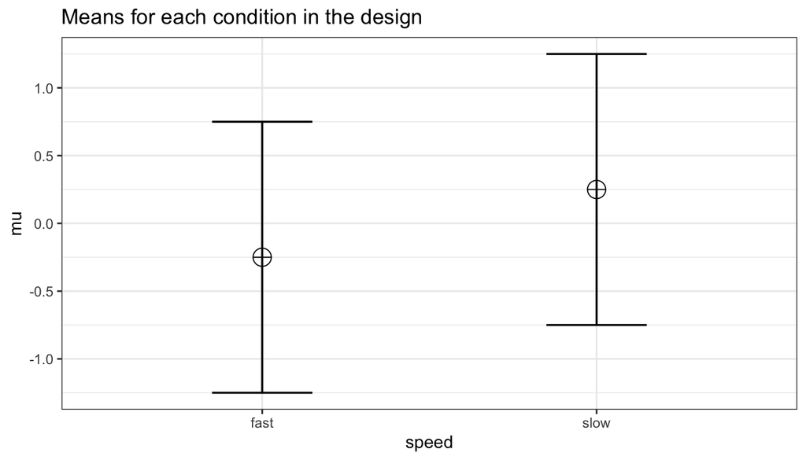

```r
ANOVA_exact(design_result)
```

```
## Power and Effect sizes for ANOVA tests
##         power partial_eta_squared cohen_f non_centrality
## speed 80.7778              0.2048  0.5075            8.5
##
## Power and Effect sizes for pairwise comparisons (t-tests)
##                         power effect_size
## p_speed_fast_speed_slow 80.78         0.5
```

模拟的结果为80.777%。需要注意的是这个模拟为配对对比计算Cohen’s $d_Z$，在此相关设定为0.5，为中等效应量。

在上述G*Power的例子中，如果我们尝试增加相关并保持样本量一致,我们也应得到稍大的$d_Z$。在如下的模拟中，我们只修改了相关的值为0.7，这将使得$d_Z=0.6454972$。

```r
K <- 2
n <- 34
sd <- 1
r <- 0.7
alpha = 0.05
f <- 0.25
f2 <- f^2
ES <- f2/(f2+1)
ES
```

```
## [1] 0.05882353
```

```r
mu <- mu_from_ES(K = K, ES = ES)
design = paste(K,"w",sep="")
labelnames <- c("speed", "fast", "slow")

design_result <- ANOVA_design(design = design,
                              n = n,
                              mu = mu,
                              sd = sd,
                              r = r,
                              labelnames = labelnames)
```

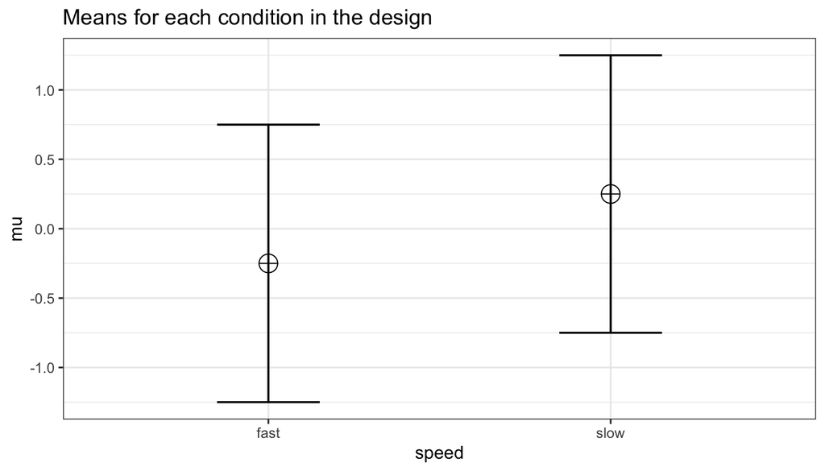

```r
ANOVA_exact(design_result)
```

```
## Power and Effect sizes for ANOVA tests
##         power partial_eta_squared cohen_f non_centrality
## speed 95.4703              0.3004  0.6552        14.1667
##
## Power and Effect sizes for pairwise comparisons (t-tests)
##                         power effect_size
## p_speed_fast_speed_slow 95.47        0.65
```

##### 2.3.10.2.2 多组重复测量ANOVA的统计检验力

我们来检验拥有3组被试内实验情况的重复测量实验，来解释一个重复测量的ANOVA来如何拓展非独立样本*t*检验。在两组被试内实验设计的例子中，我们提供了一个针对此类情形的特定的计算样本量的公式。假设正态分布和复合对称，并忽视两种检验中自由度的不同，相对于被试间实验设计所需要的样本量，在多于两组的被试内实验设计中的样本量为（Maxwell & Delaney, 2004, p. 562, eq. 47）：

$$N_W=\frac{N_B(1-\rho)}{a}$$
其中a是被试内水平的个数。

##### 2.3.10.2.3 Cohen’s f和Cohen’s d之间的关系

尽管在两组重复测量ANOVA的情况下，我们可以通过我们的检验与*t*检验和Cohen’s d的对比来解释统计检验力分析的原则，但是当我们拥有多于两组的实验条件时就变得复杂了。直接解释如何计算ANOVA的统计检验力分析的Cohen’s f和效应量更为有用。根据Cohen（1988）eq. 8.2.1, 8.2.2，Cohen’s f为：

$$f=\sqrt{\frac{\frac{\sum(\mu-\bar{\mu})^2}{N}}{\sigma}}$$

假设我们使用拥有3组情况的被试内实验设计，自变量为我们问被试在不同条件下醒来的情绪：当闹钟叫醒时、工作日自然醒时和周末自然醒时。基于试点数据，我们预期平均数为3.8、4.2和4.3（基于7点有效的情绪量表），标准差为0.9，非独立的测量值之间的相关为0.7。我们可以计算此ANOVA的Cohen’s f和事后比较的Cohen’s $d_Z$。

```r
mu <- c(3.8, 4.2, 4.3)
sd <- 0.9
f <- sqrt(sum((mu-mean(mu))^2)/length(mu))/sd #Cohen, 1988, formula 8.2.1 and 8.2.2
f
```

```
## [1] 0.2400274
```

```r
r <- 0.7
(4.2-3.8)/0.9/sqrt(2*(1-r))
```

```
## [1] 0.5737753
```

```r
(4.3-3.8)/0.9/sqrt(2*(1-r))
```

```
## [1] 0.7172191
```

```r
(4.3-4.2)/0.9/sqrt(2*(1-r))
```

```
## [1] 0.1434438
```

当拥有多组时，Cohen’s d或者$d_Z$和Cohen’s f之间的关系变得复杂，因为此关系基于平均数的模式。Cohen（1988）讲述了三类模式的计算方法：最小变异、中等变异和最大变异。针对这三种模式可根据公式由Cohen’s d来计算Cohen’s f，其中d是由最大的均值和最小的均值的差异来计算的效应量（如果最大的均值为0.25，最小的均值为-0.25，0.25-（-0.25）=0.5.所以d是0.5除以标准差0.9）。在我们的例子中，d为（4.3-3.8）/0.9 = 0.5555556。如果我们将此值除以$\sqrt{2(1-r)}$，我们可以得到$d_Z=0.5555556/0.7745967=0.7172191$。如果均值和标准差是已知的，可由这些值直接计算Cohen’s f。

我们可以使用模拟来计算被试内设计的统计检验力。我们将组别数设置为3，n = 20，变量间相关为0.8。如果真正的效应量f是0.25，alpha是0.05，那么统计检验力为96.9%。

在这种情况中，我们使用均值-0.3061862，0.0000000和0.3061862，并且设定标准差为1。

```r
K <- 3
n <- 20
sd <- 1
r <- 0.8
alpha = 0.05
f <- 0.25
f2 <- f^2
ES <- f2/(f2+1)
ES
```

```
## [1] 0.05882353
```

```r
mu <- mu_from_ES(K = K, ES = ES)
sqrt(sum((mu-mean(mu))^2)/length(mu))/sd #Cohen, 1988, formula 8.2.1 and 8.2.2
```

```
## [1] 0.25
```

```r
design = paste(K,"w",sep="")
labelnames <- c("speed", "fast", "medium", "slow")

design_result <- ANOVA_design(design = design,
                              n = n,
                              mu = mu,
                              sd = sd,
                              r = r,
                              labelnames = labelnames)
```

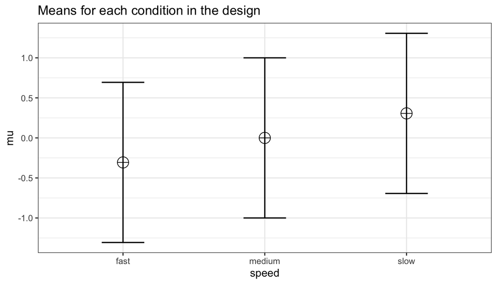

```r
nsims <- 1000 # 注：此处根据实际需要修改，例如上文提到的先设定成100，如果正确的话再修改为1000
power_result_vig_3 <- ANOVA_power(design_result, nsims = nsims)
```

```
## Power and Effect sizes for ANOVA tests
##             power effect_size
## anova_speed  96.6      0.3425
##
## Power and Effect sizes for pairwise comparisons (t-tests)
##                           power effect_size
## p_speed_fast_speed_medium  53.5      0.5016
## p_speed_fast_speed_slow    98.5      0.9996
## p_speed_medium_speed_slow  51.9      0.4982
##
##
## Within-Subject Factors Included: Check MANOVA Results
```

```r
# reduce file size for github - only save what is needed
power_result_vig_3$sim_data <- NULL
# power_result_vig_3$plot1 <- NULL
power_result_vig_3$plot2 <- NULL
saveRDS(power_result_vig_3, file = "power_result_vig_3.rds")
power_result_vig_3 <- readRDS(file = "power_result_vig_3.rds")
```

#### 2.3.10.3 例子5：被试内实验设计的2X2 ANOVA

我们可以模拟一个设定了alpha、样本量和效应量的two-way ANOVA来达到特定的统计检验力。

对于2-way交互作用，如果总样本量为46，统计检验力应为91.25%。因为被试间因素有两个水平，所以我们有2组（并且每组有2次重复测量）。

```r
mu <- c(-0.25, 0.25, 0.25, -0.25)
n <- 23
sd <- 1
r <- 0.5
design = "2w*2b"
design_result <- ANOVA_design(design = design,
                              n = n,
                              mu = mu,
                              sd = sd,
                              r = r)
```

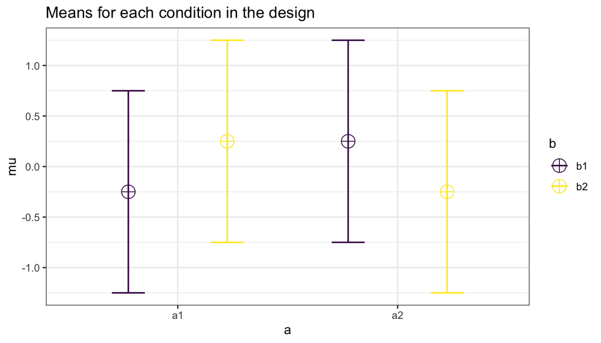

```r
ANOVA_exact(design_result)
```

```
## Power and Effect sizes for ANOVA tests
##       power partial_eta_squared cohen_f non_centrality
## b    5.0000              0.0000  0.0000            0.0
## a    5.0000              0.0000  0.0000            0.0
## b:a 91.2498              0.2072  0.5112           11.5
##
## Power and Effect sizes for pairwise comparisons (t-tests)
##                       power effect_size
## p_a_a1_b_b1_a_a1_b_b2 38.17         0.5
## p_a_a1_b_b1_a_a2_b_b1 63.02         0.5
## p_a_a1_b_b1_a_a2_b_b2  5.00         0.0
## p_a_a1_b_b2_a_a2_b_b1  5.00         0.0
## p_a_a1_b_b2_a_a2_b_b2 63.02        -0.5
## p_a_a2_b_b1_a_a2_b_b2 38.17        -0.5
```

我们可以将相关调整为0.7进而模拟同样的two-way ANOVA。统计检验力应增加至98.98%。

```r
mu <- c(-0.25, 0.25, 0.25, -0.25)
n <- 23
sd <- 1
r <- 0.7
design = "2w*2b"
design_result <- ANOVA_design(design = design,
                              n = n,
                              mu = mu,
                              sd = sd,
                              r = r)
```

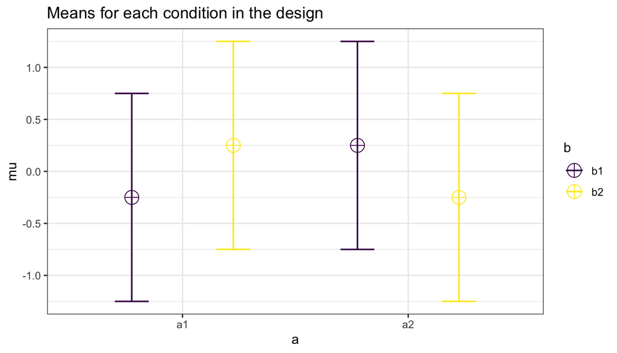

```r
ANOVA_exact(design_result)
```

```
## Power and Effect sizes for ANOVA tests
##       power partial_eta_squared cohen_f non_centrality
## b    5.0000              0.0000    0.00         0.0000
## a    5.0000              0.0000    0.00         0.0000
## b:a 98.9847              0.3034    0.66        19.1667
##
## Power and Effect sizes for pairwise comparisons (t-tests)
##                       power effect_size
## p_a_a1_b_b1_a_a1_b_b2 38.17        0.50
## p_a_a1_b_b1_a_a2_b_b1 84.09        0.65
## p_a_a1_b_b1_a_a2_b_b2  5.00        0.00
## p_a_a1_b_b2_a_a2_b_b1  5.00        0.00
## p_a_a1_b_b2_a_a2_b_b2 84.09       -0.65
## p_a_a2_b_b1_a_a2_b_b2 38.17       -0.50
```

#### 2.3.10.4 例子6：被试间实验设计的two-way ANOVA

在ANOVA中的交互作用的效应量依赖于均值的模式。假如研究者计划做一项2*2的实验：人工智能的声音是高兴或者伤心和该声音听起来更像机器人或者更像人类。我们可以期待产生不同的结果，例如不论是对于像人类的声音还是像机器人的声音，高兴的声音比伤心的声音都更让人喜欢；或者高兴的类人声比伤心的类人声更让人喜欢，而在类机器人声中高兴与伤心并无差异，或者甚至是在类机器人声中人们更喜欢伤心的声音（Marvin-the-Depressed-Robot效应）。在第一个情况中，我们将只观测声音的主效应，但是在另外两种可能的情况下，在声音的类人性和声音的情绪基调上存在交互作用。我们可以通过每组拥有80个被试的2X2的被试间实验设计的交互作用来模拟这个统计检验力。

从数学上来说，交互作用是由每一个单元格的均值减去整体的均值、每一行的边缘均值减去整体的均值和每一列的边缘均值减去整体均值来计算的。例如，对于高兴的类人声的条件来说就是$1-(0.5+0.5+0.5)=-0.5$。由计算可得，每个单元格的值为-0.5，0.5，0.5和-0.5。Cohen’s f为$f=\frac{\sqrt{\frac{(-0.5)^2+0.5^2+0.5^2+(-0.5)^2}{4}}}{2}=0.25$。模拟的结果显示当每种实验条件下有80名被试时，统计检验力为99.379%。每个因子具有两个水平的交叉（cross-over，也称无序disordinal）交互作用与最初的两组设计拥有完全相同的统计检验力。如果针对交叉交互作用的每组样本量由80变为40，相应的统计检验力为88.315%。ANOVA中的主效应是基于一个因素相对于其它因素的均值（例如，不论是快乐还是悲伤的，类人声音的主效应与类机器人声音的主效应的对比）。这种交互作用的效应可以使用1，-1，-1，1来编码，这与基于每个单元格的分数的效应是否为非相加性的测试相似，如果每个单元格的效应可以被单纯地相加的预期偏差可以被拒绝，那么非相加效应的零假设可以被拒绝。关键的点在于不是每种情况下的样本量而是在于基于所有因素的总的样本量来决定主效应和交互作用的统计检验力。

我们也可以检验表明使用高兴或者伤心的类机器人声音之间不存在差异的结果模式的统计检验力。在这种情况下，我们期望一个“序数”的交互，即类人声的均值永远不会比类机器人声的均值低，因此也就不会有交叉效应。现将均值的模式改为1，0，0，0，其中只有一个均值与其它均值不同。与两组对比相比，这种设计需要更大的样本量来拥有同样的检测到交互作用的统计检验力。原因在于效应量只有原来的一半，Cohen’s f = 0.125（在交叉交互中为0.25）。通过在模拟中稳定增加样本量，我们可以看到为了达到像两组对比的同样的统计检验力需要635名被试，几乎是两组对比的样本量（160）的四倍。

在只有一个单元格的均值与其它均值不同的2X2的序数交互的统计检验力与一个均值为其它均值的两倍大（例如2，0，0，0）的统计检验力相同。相似地，如果我们检验一个只有一个单元格与其它单元格的均值不同的2X2X2的交互，当均值为4，0，0，0，0，0，0，0时，Cohen’s f为0.25。总的来说，与无序（交叉）交互相比，在序数交互中“中等”效应量会转化为一个更为极端的均值模式,与2X2交互相比，2X2X2的交互亦是如此。因此与直接设定一个效应量相比，基于期望的均值的模式和相应计算的Cohen’s f来执行一个统计检验力分析更为直观。基于交互的种类和因素的个数，同样的效应量可代表非常不同的均值的模式。

#### 2.3.10.5 例子7: 3X3被试间实验设计的ANOVA

如果我们将实验设计中的每一个因素拓展一个水平，我们将得到一个3X3的实验设计（2个因素，每个因素3个水平）。

```r
design <- "3b*3b"
n <- 20
mu <- c(20, 20, 20, 20, 20, 20, 20, 20, 25) #All means are equal - so there is no real difference.
# Enter means in the order that matches the labels below.
sd <- 5
labelnames <- c("Factor_A", "a1", "a2", "a3", "Factor_B", "b1", "b2", "b3") #
# the label names should be in the order of the means specified above.

design_result <- ANOVA_design(design = design,
                   n = n,
                   mu = mu,
                   sd = sd,
                   labelnames = labelnames)
```

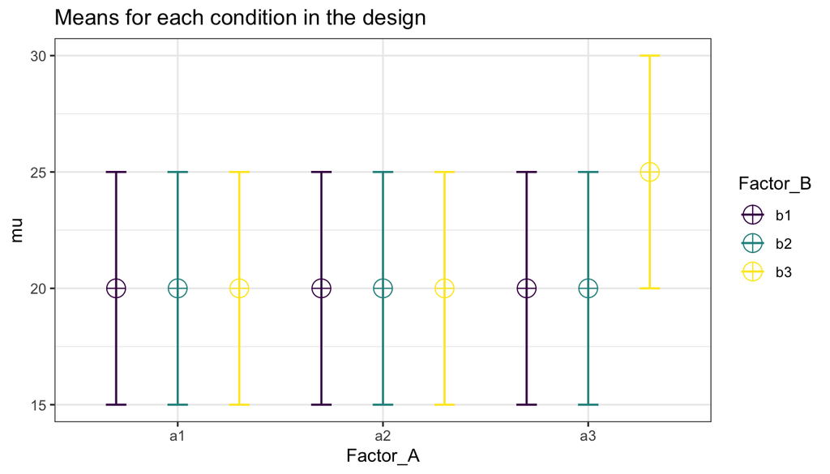

```r
ANOVA_exact(design_result, alpha_level = 0.05)
```

```
## Power and Effect sizes for ANOVA tests
##                     power partial_eta_squared cohen_f non_centrality
## Factor_A          44.8631              0.0253  0.1612         4.4444
## Factor_B          44.8631              0.0253  0.1612         4.4444
## Factor_A:Factor_B 64.3413              0.0494  0.2280         8.8889
##
## Power and Effect sizes for pairwise comparisons (t-tests)
##                                                   power effect_size
## p_Factor_A_a1_Factor_B_b1_Factor_A_a1_Factor_B_b2   5.0           0
## p_Factor_A_a1_Factor_B_b1_Factor_A_a1_Factor_B_b3   5.0           0
## p_Factor_A_a1_Factor_B_b1_Factor_A_a2_Factor_B_b1   5.0           0
## p_Factor_A_a1_Factor_B_b1_Factor_A_a2_Factor_B_b2   5.0           0
## p_Factor_A_a1_Factor_B_b1_Factor_A_a2_Factor_B_b3   5.0           0
## p_Factor_A_a1_Factor_B_b1_Factor_A_a3_Factor_B_b1   5.0           0
## p_Factor_A_a1_Factor_B_b1_Factor_A_a3_Factor_B_b2   5.0           0
## p_Factor_A_a1_Factor_B_b1_Factor_A_a3_Factor_B_b3  86.9           1
## p_Factor_A_a1_Factor_B_b2_Factor_A_a1_Factor_B_b3   5.0           0
## p_Factor_A_a1_Factor_B_b2_Factor_A_a2_Factor_B_b1   5.0           0
## p_Factor_A_a1_Factor_B_b2_Factor_A_a2_Factor_B_b2   5.0           0
## p_Factor_A_a1_Factor_B_b2_Factor_A_a2_Factor_B_b3   5.0           0
## p_Factor_A_a1_Factor_B_b2_Factor_A_a3_Factor_B_b1   5.0           0
## p_Factor_A_a1_Factor_B_b2_Factor_A_a3_Factor_B_b2   5.0           0
## p_Factor_A_a1_Factor_B_b2_Factor_A_a3_Factor_B_b3  86.9           1
## p_Factor_A_a1_Factor_B_b3_Factor_A_a2_Factor_B_b1   5.0           0
## p_Factor_A_a1_Factor_B_b3_Factor_A_a2_Factor_B_b2   5.0           0
## p_Factor_A_a1_Factor_B_b3_Factor_A_a2_Factor_B_b3   5.0           0
## p_Factor_A_a1_Factor_B_b3_Factor_A_a3_Factor_B_b1   5.0           0
## p_Factor_A_a1_Factor_B_b3_Factor_A_a3_Factor_B_b2   5.0           0
## p_Factor_A_a1_Factor_B_b3_Factor_A_a3_Factor_B_b3  86.9           1
## p_Factor_A_a2_Factor_B_b1_Factor_A_a2_Factor_B_b2   5.0           0
## p_Factor_A_a2_Factor_B_b1_Factor_A_a2_Factor_B_b3   5.0           0
## p_Factor_A_a2_Factor_B_b1_Factor_A_a3_Factor_B_b1   5.0           0
## p_Factor_A_a2_Factor_B_b1_Factor_A_a3_Factor_B_b2   5.0           0
## p_Factor_A_a2_Factor_B_b1_Factor_A_a3_Factor_B_b3  86.9           1
## p_Factor_A_a2_Factor_B_b2_Factor_A_a2_Factor_B_b3   5.0           0
## p_Factor_A_a2_Factor_B_b2_Factor_A_a3_Factor_B_b1   5.0           0
## p_Factor_A_a2_Factor_B_b2_Factor_A_a3_Factor_B_b2   5.0           0
## p_Factor_A_a2_Factor_B_b2_Factor_A_a3_Factor_B_b3  86.9           1
## p_Factor_A_a2_Factor_B_b3_Factor_A_a3_Factor_B_b1   5.0           0
## p_Factor_A_a2_Factor_B_b3_Factor_A_a3_Factor_B_b2   5.0           0
## p_Factor_A_a2_Factor_B_b3_Factor_A_a3_Factor_B_b3  86.9           1
## p_Factor_A_a3_Factor_B_b1_Factor_A_a3_Factor_B_b2   5.0           0
## p_Factor_A_a3_Factor_B_b1_Factor_A_a3_Factor_B_b3  86.9           1
## p_Factor_A_a3_Factor_B_b2_Factor_A_a3_Factor_B_b3  86.9           1
```

我们可以对照解析解决方案来检查。

```r
power_res <- power_twoway_between(design_result) #using default alpha level of .05

power_res$power_A
```

```
## [1] 44.86306
```

```r
power_res$power_B
```

```
## [1] 44.86306
```

```r
power_res$power_AB
```

```
## [1] 64.34127
```

我们可以看到当每个单元格有20名被试时，统计检验力很低。我们来看当每个实验条件下的样本量增加时，统计检验力如何增加。

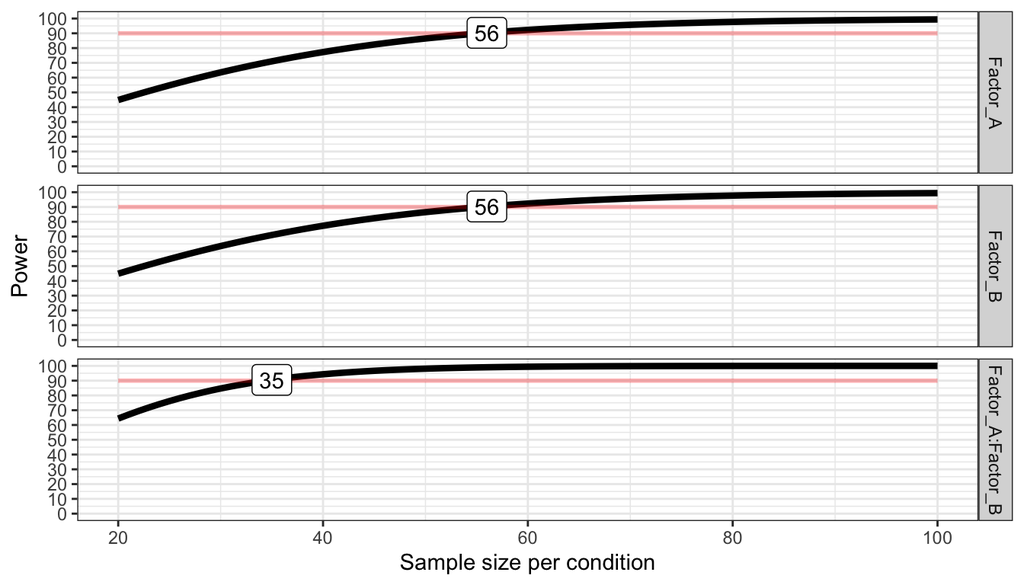

```
## Achieved Power and Sample Size for ANOVA-level effects
##            variable                  label  n achieved_power desired_power
## 1          Factor_A Desired Power Achieved 56          90.32            90
## 2          Factor_B Desired Power Achieved 56          90.32            90
## 3 Factor_A:Factor_B Desired Power Achieved 35          90.53            90
```

```r
plot_power(design_result, min_n = 20, max_n = 100)
```

#### 2.3.10.6 例子8：被试内实验设计的2X2 ANOVA

Potvin和Schulz（2000）检验了2X2的被试内ANOVA设计的统计检验力并得出误差方差的近似值。对于一个拥有2个被试内因素（A和B）的设计来说是：

对于A的主效应：$\sigma_e^2=\sigma^2(1-\bar{\rho}_A)+\sigma^2(q-1)(\bar{\rho}_B-\bar{\rho}_{AB})$

对于B的主效应：$\sigma_e^2=\sigma^2(1-\bar{\rho}_B)+\sigma^2(p-1)(\bar{\rho}_A-\bar{\rho}_{AB})$

对于A和B的交互：$\sigma_e^2=\sigma^2(1-\rho_{max})-\sigma^2(\bar{\rho}_{min}-\bar{\rho}_{AB})$

我们首先来模拟一个2X2 ANOVA被试内实验设计。

```r
mu = c(2,1,4,2)
n <- 20
sd <- 5
r <- c(
  0.8, 0.5, 0.4,
       0.4, 0.5,
            0.8
  )

design = "2w*2w"
labelnames = c("A", "a1", "a2", "B", "b1", "b2")
design_result <- ANOVA_design(design = design,
                              n = n,
                              mu = mu,
                              sd = sd,
                              r = r,
                              labelnames = labelnames)
```

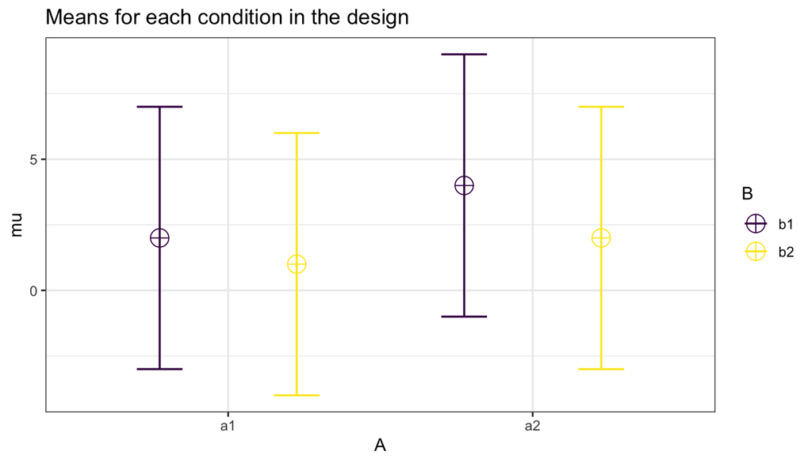

```r
nsims <- 1000 # 注：此处根据实际需要修改，例如上文提到的先设定成100，如果正确的话再修改为1000
power_result_vig_4 <- ANOVA_power(design_result, nsims = nsims)
```

```
## Power and Effect sizes for ANOVA tests
##           power effect_size
## anova_A    28.3      0.1331
## anova_B    65.0      0.2616
## anova_A:B  26.6      0.1241
##
## Power and Effect sizes for pairwise comparisons (t-tests)
##                       power effect_size
## p_A_a1_B_b1_A_a1_B_b2  29.6   -0.341356
## p_A_a1_B_b1_A_a2_B_b1  40.2    0.420747
## p_A_a1_B_b1_A_a2_B_b2   4.3    0.001738
## p_A_a1_B_b2_A_a2_B_b1  64.3    0.580583
## p_A_a1_B_b2_A_a2_B_b2  14.8    0.218098
## p_A_a2_B_b1_A_a2_B_b2  76.0   -0.656224
##
##
## Within-Subject Factors Included: Check MANOVA Results
```

```r
power_result_vig_4$sim_data <- NULL
# power_result_vig_4$plot1 <- NULL
power_result_vig_4$plot2 <- NULL
saveRDS(power_result_vig_4, file = "power_result_vig_4.rds")
power_result_vig_4 <- readRDS(file = "power_result_vig_4.rds")
```

我们也可以使用exact模拟。

```r
ANOVA_exact(design_result = design_result)
```

```
## Power and Effect sizes for ANOVA tests
##       power partial_eta_squared cohen_f non_centrality
## A   26.9175              0.0952  0.3244              2
## B   64.2259              0.2400  0.5620              6
## A:B 26.9175              0.0952  0.3244              2
##
## Power and Effect sizes for pairwise comparisons (t-tests)
##                       power effect_size
## p_A_a1_B_b1_A_a1_B_b2 26.92       -0.32
## p_A_a1_B_b1_A_a2_B_b1 39.70        0.40
## p_A_a1_B_b1_A_a2_B_b2  5.00        0.00
## p_A_a1_B_b2_A_a2_B_b1 64.23        0.55
## p_A_a1_B_b2_A_a2_B_b2 13.60        0.20
## p_A_a2_B_b1_A_a2_B_b2 76.52       -0.63
```

我们可以看到26.9、64.2和26.9都与exact模拟的结果一致。

## 2.4 PANGEA

## 2.5 LMM Power

## 2.6 power analysis in fMRI

## 2.7 Bayesian power analysis